# Lecture 16: Exploring multiple regression

**Learning Objectives**: See how coefficients, p-values, and predictions change when you add and remove variables from a multiple linear regression model.

**Instructions**: Submit written answers to the numbered questions on pencil and paper! This activity is Mini Quiz 6! You don’t need to write a ton in your answers, but I should be able to tell that you were making progress and learning something! You can work in groups!

# Getting Started

I made you three fake datasets to explore some properties of multiple regression. Download them with the following code:

```r
library(tidyverse)
dat.small <- read.csv("https://anna-neufeld.github.io/stat202_tutorials/Week9/dat.small.csv")
dat.big <- read.csv("https://anna-neufeld.github.io/stat202_tutorials/Week9/dat.big.csv")
dat.big.test <- read.csv("https://anna-neufeld.github.io/stat202_tutorials/Week9/dat.big.test.csv")
```

# 1. Starting with dat.small

This dataset has 30 observations, one response variable `y`, and $7$ predictor variables `x1`, `x2`, …, `x7`. The following code will show you relationships between all of your variables.

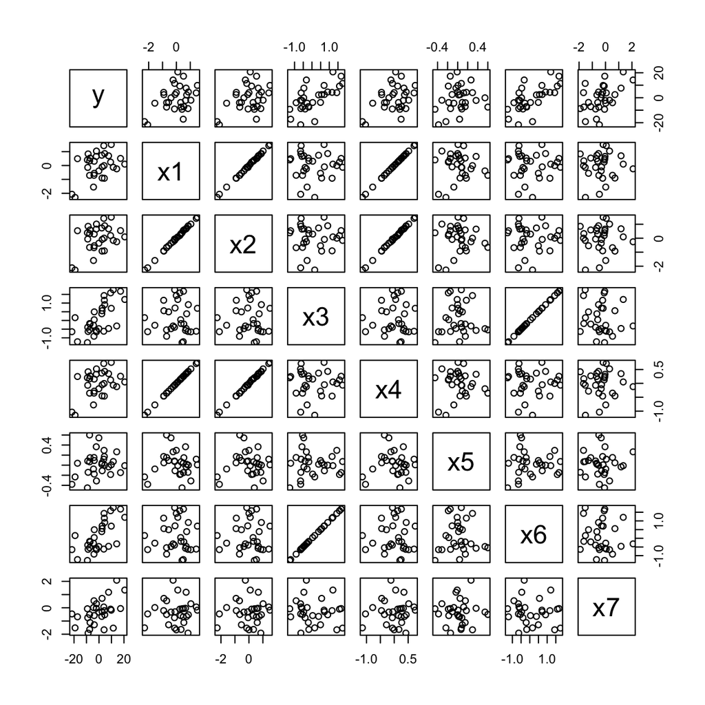

```r
pairs(dat.small)
```

The following code and output tells you about the pairwise correlations between all variables in your dataset.For example, 0.395 is the correlation between $y$ and $x2$ in this dataset. The values on the diagonal are all $1$, since every variable is perfectly correlated with itself!

```r
cor(dat.small)
```

|  | y | x1 | x2 | x3 | x4 | x5 | x6 | x7 |
| --- | --- | --- | --- | --- | --- | --- | --- | --- |
| y | 1.0000000 | 0.4037688 | 0.3953713 | 0.6584705 | 0.4037688 | 0.1849520 | 0.6589385 | 0.4923300 |
| x1 | 0.4037688 | 1.0000000 | 0.9994114 | 0.0000000 | 1.0000000 | 0.0153318 | 0.0011602 | 0.0578495 |
| x2 | 0.3953713 | 0.9994114 | 1.0000000 | -0.0041397 | 0.9994114 | 0.0308933 | -0.0029802 | 0.0471196 |
| x3 | 0.6584705 | 0.0000000 | -0.0041397 | 1.0000000 | 0.0000000 | 0.0009792 | 0.9999993 | -0.1126423 |
| x4 | 0.4037688 | 1.0000000 | 0.9994114 | 0.0000000 | 1.0000000 | 0.0153318 | 0.0011602 | 0.0578495 |
| x5 | 0.1849520 | 0.0153318 | 0.0308933 | 0.0009792 | 0.0153318 | 1.0000000 | 0.0009970 | 0.0266500 |
| x6 | 0.6589385 | 0.0011602 | -0.0029802 | 0.9999993 | 0.0011602 | 0.0009970 | 1.0000000 | -0.1125751 |
| x7 | 0.4923300 | 0.0578495 | 0.0471196 | -0.1126423 | 0.0578495 | 0.0266500 | -0.1125751 | 1.0000000 |

We will now try out a bunch of regressions of `y` on subsets of the predictor variables `x1`,…,`x7`. For each exercise, try out some code in your console, and then record a handwritten answer on your mini quiz.

**1a: Highly correlated predictors:** Compare a linear regression of `y` on `x1` to a linear regression of `y` on `x1` and `x2`. Specifically, compare your two models in terms of: the coefficient for `x1`, its standard error, its p-value, and $R^2$. What did you learn from this problem?

*The coefficient on x1 changes a LOT between the two models. In the model that includes x1 and x2, the standard error is quite high, and therefore we do not have a small p-value or statistical significance. This is despite the fact that I can see from `pairs()` that `x1` really is associated with `y`.*

```r
mod1 <- lm(y~x1, data=dat.small)
mod12 <- lm(y~x1+x2, data=dat.small)
summary(mod1)$coefficients[2,]
```

```
##   Estimate Std. Error    t value   Pr(>|t|)
## 4.43943982 1.90095346 2.33537533 0.02691591
```

```r
summary(mod12)$coefficients[2,]
```

```
##   Estimate Std. Error    t value   Pr(>|t|)
## 80.6248397 54.4872566  1.4797008  0.1505275
```

*Even though the model with `x1` and `x2` has no statistical significance, its $R^2$ is higher than the model with only `x1`.*

```r
summary(mod1)$r.squared
```

```
## [1] 0.1630293
```

```r
summary(mod12)$r.squared
```

```
## [1] 0.2196033
```

*The issue here is that x1 and x2 are very highly correlated. So the model with x1 and x2 is giving x1 a massive positive coefficient and x2 a massive negative coefficient, and we are ending up with similar predictions from the two models. But this tradeoff between x1 and x2 is not really useful for interpretation. The plot below shows that the two models have similar predictions, despite having very different coefficients and standard errors.*

```r
cor(dat.small$x1, dat.small$x2)
```

```
## [1] 0.9994114
```

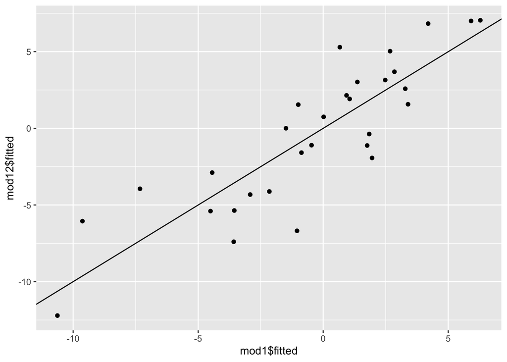

```r
ggplot(data=NULL, aes(x=mod1$fitted, y=mod12$fitted))+geom_point()+
  geom_abline(slope=1, intercept=0)
```

**1b: Perfectly uncorrelated predictors:** Compare a linear regression of `y` on `x1` to a linear regression of `y` on `x1` and `x3`. What do you notice about: the coefficient on `x1`, its standard error, and its p-value. Also, what do you notice about $R^2$? What did you learn from this problem?

*We now get the exact same slope in the two models, but the standard errors and p-values are a bit different because the residual standard error has changed. We can tell the residual standard error has changed because $R^2$ is much higher- we got much better predictions. Here, we have clearly improved our model by adding a totally new piece of information!!!! But because x3 was not a confounder (not correlated with x1), it did not change our takeaways from our first model.*

```r
cor(dat.small$x1, dat.small$x3)
```

```
## [1] -1.772507e-16
```

```r
mod13 <- lm(y~x1+x3, data=dat.small)

summary(mod13)$coefficients[2,]
```

```
##    Estimate  Std. Error     t value    Pr(>|t|)
## 4.439439821 1.343923741 3.303342062 0.002697796
```

```r
summary(mod1)$coefficients[2,]
```

```
##   Estimate Std. Error    t value   Pr(>|t|)
## 4.43943982 1.90095346 2.33537533 0.02691591
```

```r
summary(mod13)$r.squared
```

```
## [1] 0.5966126
```

```r
summary(mod1)$r.squared
```

```
## [1] 0.1630293
```

**1c: Perfectly correlated predictors:** What happens if you fit a linear regression of `y` on `x1` and `x4`? What do you learn from this?

```r
summary(lm(y~x1+x4, data=dat.small))
```

```
##
## Call:
## lm(formula = y ~ x1 + x4, data = dat.small)
##
## Residuals:
##      Min       1Q   Median       3Q      Max
## -18.9612  -7.5287  -0.5292   4.8843  20.6462
##
## Coefficients: (1 not defined because of singularities)
##             Estimate Std. Error t value Pr(>|t|)
## (Intercept)  -0.4307     1.7272  -0.249   0.8049
## x1            4.4394     1.9010   2.335   0.0269 *
## x4                NA         NA      NA       NA
## ---
## Signif. codes:  0 '***' 0.001 '**' 0.01 '*' 0.05 '.' 0.1 ' ' 1
##
## Residual standard error: 9.46 on 28 degrees of freedom
## Multiple R-squared:  0.163,  Adjusted R-squared:  0.1331
## F-statistic: 5.454 on 1 and 28 DF,  p-value: 0.02692
```

**1d: Mostly uncorrelated predictors:** What happens if you fit a linear regression of `y` on `x1` and `x5` and `x6` and `x7`. How does this model compare to ones from the previous parts? Play around with this model by adding or removing one variable at a time, and be sure to check out the correlations between different pairs of these variables. What did you learn from this, and how does it relate to the previous parts of the question?

*The coefficients definitely change a bit if you add and remove variables. There is non-zero correlation between the Xs and all variables besides x5 seem important for predicting $y$. We now have quite a large $R^2$, so all of these seem useful. If we were to suddenly add x2, we would ruin some statistical significance but not ruin $R^2$.*

```r
mod167 <- lm(y~x1+x6+x7, data=dat.small)
summary(mod167)
```

[output not shown]

**1e: What would be your pick for a “final model” for this dataset?**